# Regression: predictive modelling – Part 2

ENVX2001 - Applied Statistical Methods

Liana Pozza

The University of Sydney

Apr 2024

# Recap

## Model validation workflow

1. **Split** the data into training and test sets (not necessary for cross-validation techniques)
2. **Develop model(s)** on the training set (includes variable selection).
3. **Validate** the model(s) by comparing to the test set:
   - **RMSE** - root mean squared error: a measure of accuracy.
     - *The lower, the better*
   - **ME** - mean error: a measure of bias.
     - *The closer to 0, the better*
   - **CCC** - concordance correlation coefficient: a measure of agreement/precision.
     - *The closer to 1, the better*

# Example: Loyn dataset

## About

Data on the relationship between bird abundance (bird ha<sup>-1</sup>) and the characteristics of forest patches at 56 locations in SE Victoria.

The predictor variables are:

- `ALT` Altitude (m)
- `YR.ISOL` Year when the patch was isolated (years)
- `GRAZE` Grazing (coded 1-5 which is light to heavy)
- `AREA` Patch area (ha)
- `DIST` Distance to nearest patch (km)
- `LDIST` Distance to largest patch (km)

```r
library(readxl)
loyn <- read_xlsx("assets/mlr.xlsx", "Loyn")
```

## Dataset splitting

We will split the data into training and test sets.

**Note**

Sometimes, the training and tests sets are also called the *calibration* and *validation* sets, respectively.

As the dataset is quite small, we will use a 80:20 split.

```r
set.seed(100)
indexes <- sample(1:nrow(loyn), size = 0.2 * nrow(loyn))
loyn_train <- loyn[-indexes, ] # use this to create model
loyn_test <- loyn[indexes, ] # use this to validate model
```

## Checking the split

Have a quick `glimpse()` of the data to see if the split worked. If your data does not look the same as below, you may have forgotten to set the seed.

```r
library(tidyverse)
glimpse(loyn_train)
```

```
Rows: 45
Columns: 7
$ ABUND   <dbl> 5.3, 2.0, 1.5, 17.1, 13.8, 3.8, 2.2, 3.3, 27.6, 1.8, 21.2, 8.0…
$ AREA    <dbl> 0.1, 0.5, 0.5, 1.0, 1.0, 1.0, 1.0, 1.0, 2.0, 2.0, 2.0, 2.0, 2.…
$ YR.ISOL <dbl> 1968, 1920, 1900, 1966, 1918, 1955, 1920, 1965, 1926, 1890, 19…
$ DIST    <dbl> 39, 234, 104, 66, 246, 467, 284, 156, 66, 93, 39, 259, 130, 26…
$ LDIST   <dbl> 39, 234, 311, 66, 246, 467, 1829, 156, 332, 93, 39, 259, 623, …
$ GRAZE   <dbl> 2, 5, 5, 3, 5, 5, 5, 4, 3, 5, 2, 5, 5, 3, 3, 3, 2, 2, 1, 3, 3,…
$ ALT     <dbl> 160, 60, 140, 160, 140, 90, 60, 130, 210, 160, 210, 120, 145, …
```

```r
glimpse(loyn_test)
```

```
Rows: 11
Columns: 7
$ ABUND   <dbl> 3.0, 29.5, 26.0, 39.6, 34.4, 19.5, 14.6, 28.3, 15.8, 5.0, 14.1
$ AREA    <dbl> 1, 973, 18, 49, 96, 6, 2, 34, 5, 4, 1
$ YR.ISOL <dbl> 1900, 1970, 1966, 1972, 1976, 1890, 1972, 1965, 1965, 1923, 19…
$ DIST    <dbl> 311, 337, 40, 1427, 39, 93, 402, 66, 39, 26, 234
$ LDIST   <dbl> 571, 1323, 3188, 1557, 519, 226, 402, 345, 39, 2205, 285
$ GRAZE   <dbl> 5, 1, 2, 1, 2, 3, 1, 1, 3, 5, 3
$ ALT     <dbl> 130, 190, 190, 180, 175, 170, 210, 110, 130, 120, 130
```

# Model development

From now on, we will work with the **training set only**.

## Explore

- The next step is to visualise the data.
- Expore relationships between the predictors and the response.
  - Histograms
  - Correlation plots
  - Boxplots

In this lecture we will just look at histograms.

## Histograms

```r
library(Hmisc)
hist(loyn_train, nclass = 20)
```

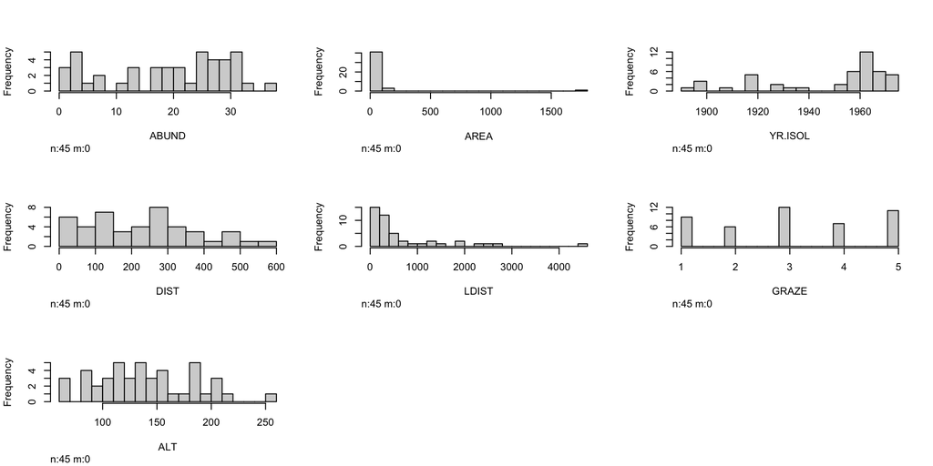

- Looks like `AREA` `LDIST` and `DIST` are skewed – we will transform them so that they are more normally distributed.

## Transforming predictors

We will use `log10()` to transform the predictors. The `mutate()` function from the `dplyr` package is useful for this as it can create new columns in the data frame with the transformed values.

```r
loyn_train <- loyn_train %>%
    mutate(
        AREA_L10 = log10(AREA),
        LDIST_L10 = log10(LDIST),
        DIST_L10 = log10(DIST)
    )
```

Then, remove the untransformed variables from the dataset. Here we can use the `select()` function from the `dplyr` package to “delselect” columns by using the `-` sign.

```r
loyn_train <- loyn_train %>%
    select(-AREA, -LDIST, -DIST)
glimpse(loyn)
```

```
Rows: 56
Columns: 7
$ ABUND   <dbl> 5.3, 2.0, 1.5, 17.1, 13.8, 14.1, 3.8, 2.2, 3.3, 3.0, 27.6, 1.8…
$ AREA    <dbl> 0.1, 0.5, 0.5, 1.0, 1.0, 1.0, 1.0, 1.0, 1.0, 1.0, 2.0, 2.0, 2.…
$ YR.ISOL <dbl> 1968, 1920, 1900, 1966, 1918, 1965, 1955, 1920, 1965, 1900, 19…
$ DIST    <dbl> 39, 234, 104, 66, 246, 234, 467, 284, 156, 311, 66, 93, 39, 40…
$ LDIST   <dbl> 39, 234, 311, 66, 246, 285, 467, 1829, 156, 571, 332, 93, 39, …
$ GRAZE   <dbl> 2, 5, 5, 3, 5, 3, 5, 5, 4, 5, 3, 5, 2, 1, 5, 5, 3, 3, 3, 2, 2,…
$ ALT     <dbl> 160, 60, 140, 160, 140, 130, 90, 60, 130, 130, 210, 160, 210, …
```

## Final inspection

View the histograms again to check that the transformation worked.

```r
hist(loyn_train, nclass = 20)
```

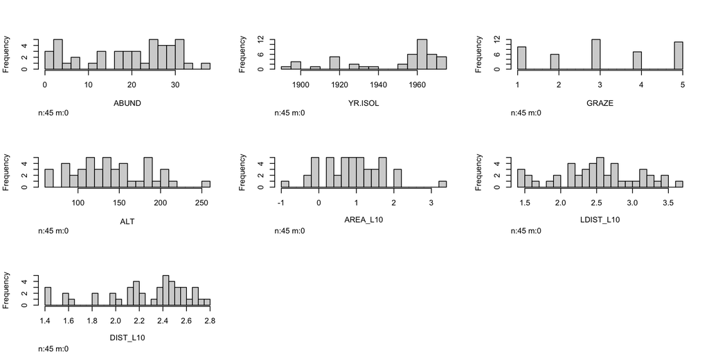

## Full model

We start with a full model that includes all the predictors.

```r
full_fit <- lm(ABUND ~ ., data = loyn_train)
summary(full_fit)
```

```
Call:
lm(formula = ABUND ~ ., data = loyn_train)

Residuals:
     Min       1Q   Median       3Q      Max
-17.3445  -3.4647   0.1991   2.8689  14.1844

Coefficients:
              Estimate Std. Error t value Pr(>|t|)
(Intercept) -159.27533  109.13660  -1.459   0.1527
YR.ISOL        0.09334    0.05392   1.731   0.0916 .
GRAZE         -1.40912    1.03653  -1.359   0.1820
ALT            0.01657    0.02810   0.589   0.5590
AREA_L10       8.09629    1.78591   4.533 5.63e-05 ***
LDIST_L10      2.05115    3.23927   0.633   0.5304
DIST_L10      -6.18596    4.83189  -1.280   0.2082
---
Signif. codes:  0 '***' 0.001 '**' 0.01 '*' 0.05 '.' 0.1 ' ' 1

Residual standard error: 6.497 on 38 degrees of freedom
Multiple R-squared:  0.6752,    Adjusted R-squared:  0.6239
F-statistic: 13.17 on 6 and 38 DF,  p-value: 5.277e-08
```

## Assumptions - Round 1

As usual, we should check the assumptions of the model. We will use the `check_model()` function from the `perfomance` package as it also has VIF plots, which we will use.

```r
library(performance)
check_model(full_fit)
```

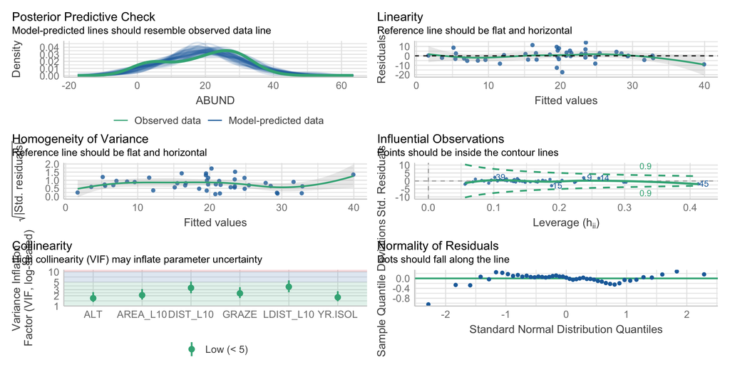

- Overall, all the assumptions are met. VIFs are all < 10, so no multicollinearity.

# Variable selection

## Backwards stepwise selection

Use the `step()` function perform backwards stepwise selection. This function uses AIC to select the best model.

Depending on the dataset splitting, the best model may be different each time we randomly sample the data. In this case we should all have the same results as we set the seed.

```r
step_fit <- step(full_fit, direction = "backward")
```

```
Start:  AIC=174.81
ABUND ~ YR.ISOL + GRAZE + ALT + AREA_L10 + LDIST_L10 + DIST_L10

            Df Sum of Sq    RSS    AIC
- ALT        1     14.67 1618.5 173.22
- LDIST_L10  1     16.92 1620.8 173.28
- DIST_L10   1     69.18 1673.0 174.71
<none>                   1603.9 174.81
- GRAZE      1     78.00 1681.9 174.94
- YR.ISOL    1    126.48 1730.3 176.22
- AREA_L10   1    867.44 2471.3 192.26

Step:  AIC=173.22
ABUND ~ YR.ISOL + GRAZE + AREA_L10 + LDIST_L10 + DIST_L10

            Df Sum of Sq    RSS    AIC
- LDIST_L10  1     10.76 1629.3 171.52
<none>                   1618.5 173.22
- DIST_L10   1     85.56 1704.1 173.54
- GRAZE      1     98.23 1716.8 173.87
- YR.ISOL    1    117.80 1736.3 174.38
- AREA_L10   1   1088.05 2706.6 194.35

Step:  AIC=171.52
ABUND ~ YR.ISOL + GRAZE + AREA_L10 + DIST_L10

           Df Sum of Sq    RSS    AIC
<none>                  1629.3 171.52
- GRAZE     1     93.97 1723.3 172.04
- YR.ISOL   1    107.73 1737.0 172.40
- DIST_L10  1    114.60 1743.9 172.57
- AREA_L10  1   1161.66 2791.0 193.74
```

- If we compare to the full model, the adjusted r-squared is slightly higher, and the AIC is lower.

## The selected model

```r
summary(step_fit)
```

```
Call:
lm(formula = ABUND ~ YR.ISOL + GRAZE + AREA_L10 + DIST_L10, data = loyn_train)

Residuals:
     Min       1Q   Median       3Q      Max
-18.1683  -3.1961   0.3374   3.4834  14.2021

Coefficients:
              Estimate Std. Error t value Pr(>|t|)
(Intercept) -135.17508  102.72850  -1.316    0.196
YR.ISOL        0.08323    0.05118   1.626    0.112
GRAZE         -1.50496    0.99082  -1.519    0.137
AREA_L10       8.61888    1.61392   5.340 3.98e-06 ***
DIST_L10      -4.87726    2.90770  -1.677    0.101
---
Signif. codes:  0 '***' 0.001 '**' 0.01 '*' 0.05 '.' 0.1 ' ' 1

Residual standard error: 6.382 on 40 degrees of freedom
Multiple R-squared:  0.6701,    Adjusted R-squared:  0.6371
F-statistic: 20.31 on 4 and 40 DF,  p-value: 3.365e-09
```

## Assumptions - Round 2

```r
check_model(step_fit)
```

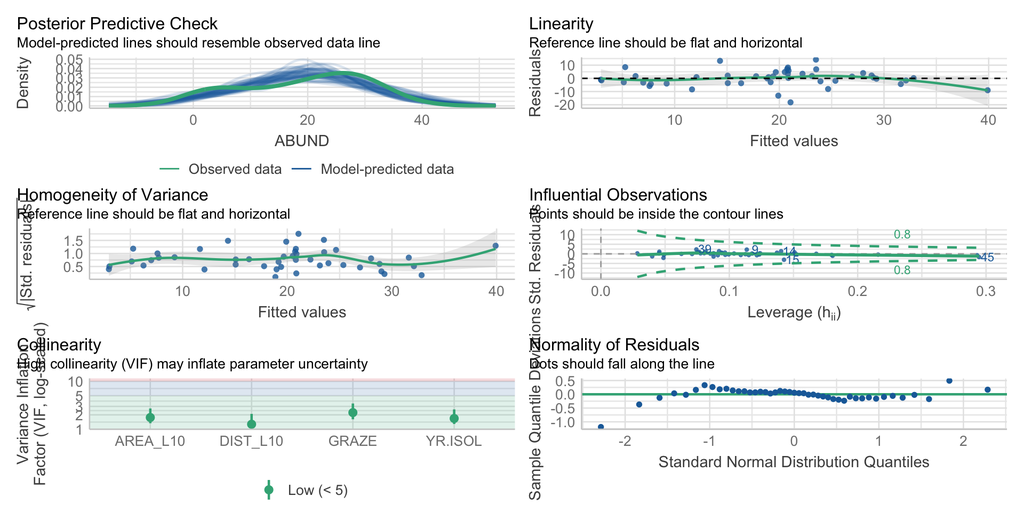

# Model validation

It looks like the model is good, so let’s bring in the test set to see how it performs!

## Assess prediction quality

- RMSE: root mean squared error

- ME: mean error - also commonly called **bias**

$$ME = \frac{1}{n} \sum_{i=1}^{n} (y_i - \hat{y}_i)$$

- CCC: Lin’s concordance correlation coefficient
- We will also look at correlations (so as to compare with CCC)
- All of these have been implemented as functions in various packages, so we can also use those.

## Performing the tests

```r
library(caret)
library(epiR)
```

The following functions are available:

- `RMSE()` from the `caret` package: `RMSE(y, y_hat)`
- `epi.ccc()` from the `epiR` package: `epi.ccc(y, y_hat)`
- `cor()` from base R: `cor(y, y_hat)`

We need to use calculations for ME: `mean(y - y_hat)`

Recall:

- full model: `full_fit`
- stepwise model: `step_fit`
- test data: `loyn_test`

## Prepare the test data

Since the test data has not been transformed, we need to do that first.

```r
loyn_test <- loyn_test %>%
    mutate(
        AREA_L10 = log10(AREA),
        LDIST_L10 = log10(LDIST),
        DIST_L10 = log10(DIST)
    ) %>%
    select(-AREA, -LDIST, -DIST)
```

## Perform tests (1)

#### RMSE - lower is better

```r
RMSE(loyn_train$ABUND, predict(step_fit))
```

```
[1] 6.017196
```

```r
RMSE(loyn_test$ABUND, predict(step_fit, newdata = loyn_test))
```

```
[1] 6.718147
```

*RMSE is larger in the test set because the model was not trained on that data. Looks like the model is overfitting.*

```r
mean(loyn_train$ABUND - predict(step_fit))
```

```
[1] -1.421085e-15
```

```r
mean(loyn_test$ABUND - predict(step_fit, newdata = loyn_test))
```

```
[1] -1.654071
```

*ME is smaller in the training set because of the larger sample size.*

## Perform tests (2)

Correlation - higher is better

```r
cor(loyn_train$ABUND, predict(step_fit))
```

```
[1] 0.8185731
```

```r
cor(loyn_test$ABUND, predict(step_fit, newdata = loyn_test))
```

```
[1] 0.8226011
```

*Correlation is similar in both sets.*

CCC - higher is better

```r
epi.ccc(loyn_train$ABUND, predict(step_fit))$rho.c
```

```
        est     lower     upper
1 0.8024397 0.6769108 0.8826113
```

```r
epi.ccc(loyn_test$ABUND, predict(step_fit, newdata = loyn_test))$rho.c
```

```
        est     lower     upper
1 0.8121518 0.4533066 0.9444561
```

## Conclusions

```r
# put all data into a tible and kable it
tibble(
    Dataset = c("Training", "Test"),
    RMSE = c(
        RMSE(loyn_train$ABUND, predict(step_fit)),
        RMSE(loyn_test$ABUND, predict(step_fit, newdata = loyn_test))
    ),
    ME = c(
        mean(loyn_train$ABUND - predict(step_fit)),
        mean(loyn_test$ABUND - predict(step_fit, newdata = loyn_test))
    ),
    COR = c(
        cor(loyn_train$ABUND, predict(step_fit)),
        cor(loyn_test$ABUND, predict(step_fit, newdata = loyn_test))
    ),
    CCC = c(
        epi.ccc(loyn_train$ABUND, predict(step_fit))$rho.c[[1]],
        epi.ccc(loyn_test$ABUND, predict(step_fit, newdata = loyn_test))$rho.c[[1]]
    )
) %>%
    knitr::kable()
```

| Dataset | RMSE | ME | COR | CCC |
| --- | --- | --- | --- | --- |
| Training | 6.017196 | 0.000000 | 0.8185731 | 0.8024397 |
| Test | 6.718147 | -1.654071 | 0.8226011 | 0.8121518 |

# Thanks!

**Questions? Comments?**

Slides made with [Quarto](https://quarto.org)